# Linear Discriminant Analysis: EMC vs Fisher’s LDA

I use the terms “group”, “cluster” and “class” interchangeably.

# Overview

In multivariate classification we typically distinguish two perspectives:

1. **Expected cost of misclassification (EMC)**
2. **Fisher’s Linear Discriminant Analysis (LDA)**

These two techniques appear to arise from different motivations, yet under specific assumptions they yield the same classification rule.

# Paradigms

## 1. Expected Cost of Misclassification (EMC)

EMC frames classification as a decision‐theoretic problem:

- **Prior class probabilities** $\pi_i$ may differ across classes.
- **Misclassification costs** $c(j|i)$ (cost of assigning to class $j$ when true class is $i$) can vary.
- **Class‐conditional densities** $f_i(\symbf{x})$ may differ in shape and scale.

> **Rule**: Allocate an observation $\symbf{x}$ to the class $j$ that minimises the expected cost

$$\mathrm{EMC}(j \mid \symbf{x})
= \sum_{i} c(j|i)\,\pi_i\,f_i(\symbf{x})\,.$$

## 2. Fisher’s Linear Discriminant Analysis

Fisher’s LDA seeks a low‐dimensional projection that maximises class separability.

### Key matrices

- **Between‐class covariance** matrix

  $$\symbf{B}^{\ast} = \frac{1}{g-1}\sum_{i=1}^g n_i (\bar{\symbf{x}}_i - \bar{\symbf{x}})\,(\bar{\symbf{x}}_i - \bar{\symbf{x}})^\top\,,$$

  where $g$ is the number of groups, $n_i$ the size of group $i$, $\bar{\symbf{x}}_i$ the group mean, and $\bar{\symbf{x}}$ the overall mean.
  - The matrix $\symbf{B}=(g-1)\symbf{B}^{\ast}$ is the “unnormalised” version of the between‐class covariance matrix.
    - This is sometimes called the between‐class scatter matrix.
- **Within‐class covariance** matrix

  $$\symbf{W}^{\ast} = \frac{1}{n-g}\sum_{i=1}^g \sum_{j=1}^{n_i} (\symbf{x}_{ij}-\bar{\symbf{x}}_i)(\symbf{x}_{ij}-\bar{\symbf{x}}_i)^\top\,,$$

  with $n = \sum_i n_i$.
  - This is the same as the pooled covariance matrix when the groups have equal covariance matrices (denoted $S_{pooled}$ in the slides), as we assume in Fisher’s LDA. Therefore, we will use the notation $S_{pooled}$ for the within‐class covariance matrix.
  - The matrix $\symbf{W}=(n-g) \symbf{W}^{\ast}$ is the “unnormalised” version of the within‐class covariance matrix.
    - This is sometimes called the within‐class scatter matrix.

### Objective

- For the first discriminant, find $\symbf{a}$ to maximise the following:

  $$\frac{\symbf{a}^\top B\,\symbf{a}}{\symbf{a}^\top W\,\symbf{a}}\, \text{ subject to } \symbf{a}^\top\symbf{S}_{pooled}\symbf{a}=1\,.$$
- The solution is given by the eigenvector of $\symbf{W}^{-1}\symbf{B}$ associated with its largest eigenvalue, scaled such that $\symbf{a}^\top\symbf{S}_{pooled}\symbf{a}=1$.
- For later discriminants, the same objective is used but with the additional restriction of orthogonality to the previous discriminants:

$$\frac{\symbf{a}_k^\top B\,\symbf{a}_k}{\symbf{a}_k^\top W\,\symbf{a}_k}\,,
\quad \text{subject to } \symbf{a}^\top\symbf{S}_{pooled}\symbf{a}=1 \text{ and } \symbf{a}_k^\top \symbf{a}_j = 0 \text{ for } j < k.$$

- The solution is given by the eigenvector of $\symbf{W}^{-1}\symbf{B}$ associated with the $k$-th largest eigenvalue, $\symbf{a}^\top\symbf{S}_{pooled}\symbf{a}=1$.

### Classification

- We don’t specifically cover this in the slides (and this is not asked in the exam), but to classify new observation $\symbf{z}$ using $r$ discriminants, the following steps are taken:
1. Obtain the first $r$ discriminant functions (first $r$ eigenvectors of $\symbf{W}^{-1}\symbf{B}$, each scaled so that $\symbf{a}_i^\top\symbf{S}_{pooled}\symbf{a}_i=1\;\forall i$): $\symbf{a}_1, \ldots, \symbf{a}_r$.
2. Calculate the $r$-dimensional projection for each class mean:
   $$\symbf{z}_i = \left( \symbf{a}_1^\top \bar{\symbf{x}}_i, \symbf{a}_2^\top \bar{\symbf{x}}_i, \ldots, \symbf{a}_r^\top \bar{\symbf{x}}_i \right),$$
   where the $j$-th element of $\bar{\symbf{x}}_i$ is the mean of the $i$-th class for the $j$-th variable.
3. Project the new observation $\symbf{x}$ onto the discriminants:
   $$\symbf{z} = \left( \symbf{a}_1^\top \symbf{x}, \symbf{a}_2^\top \symbf{x}, \ldots, \symbf{a}_r^\top \symbf{x} \right).$$
4. Each projected observation $z$ is then assigned to the class whose projected mean is closest. In other words, classify $\symbf{z}$ to class $i$ if

$$\|\symbf{z} - \symbf{z}_i\|^2$$

is minimal among all classes $i$.

## Equivalence of EMC and Fisher’s LDA

Fisher’s LDA is a restricted version of the EMC rule, yielding equivalent classification rules when:

- All class‐conditional densities $f_i(\symbf{x})$ are multivariate normal.
- All covariance matrices $\Sigma_i$ are equal, i.e., $\Sigma_i = \Sigma$ for all $i$.
- All prior class probabilities $\pi_i$ are equal, i.e., $\pi_i = 1/g$ for $i=1,\ldots,g$.
- All misclassification costs $c(j|i)$ are equal, i.e., $c(j|i)=c$ for some constant $c$, $i\neq j$ and $c(i|i)=0$.

## From two-group to multi-group

Both EMC and Fisher’s LDA are introduced for the two-group case:

- **Two-group slides** (DA.pptx [slides 2–19]):
  - EMC: slides 2–8, 11 (quadratic), 13–15 (error‐rate example using EMC)
  - Fisher’s LDA: slides 9–10, 16–19 (example)

They extend naturally to $g>2$:

- **Multi-group slides** (DA.pptx [slides 20–30]):
  - EMC: slides 20–21, 29 (package implementation)
  - Fisher’s LDA: slides 22, 26–28, 30

# LDA from First Principles for Multigroup Classification

In the exam you will implement **multigroup classification using LDA** from first principles. This closely parallels Principal Component Analysis (PCA), in creating new variables as linear combinations of the original variables, but with a different objective:

| Aspect | PCA | LDA |
| --- | --- | --- |
| Goal | Maximise variance of projections | Maximise separation between classes |
| Maximisation criterion | $\symbf{a}^\top S\,\symbf{a}$ | $\symbf{a}^\top B\,\symbf{a}\,/\,\symbf{a}^\top W\,\symbf{a}$ |
| Solution | Eigenvector of $S=\symbf{X}'\symbf{X}$ | Eigenvector of $\symbf{W}^{-1}\symbf{B}$ |

LDA is like a class-aware version of PCA, where the goal is to find linear combinations of the original variables that best separate the classes rather than just maximising variance.

Implementation follows the same steps:

1. Calculate some matrix
2. Obtain its eigenvectors
3. Take the dot product with the data matrix to obtain the new variables.

Interpretation of the variables relies on the loading vectors (the scaled eigenvectors). The new variables may be plotted, or used in downstream analysis, e.g. classification.

## Two-group example

We simulate two groups of data, each with two variables, and compute the first linear discriminant using LDA from first principles.

**Show/Hide Code**

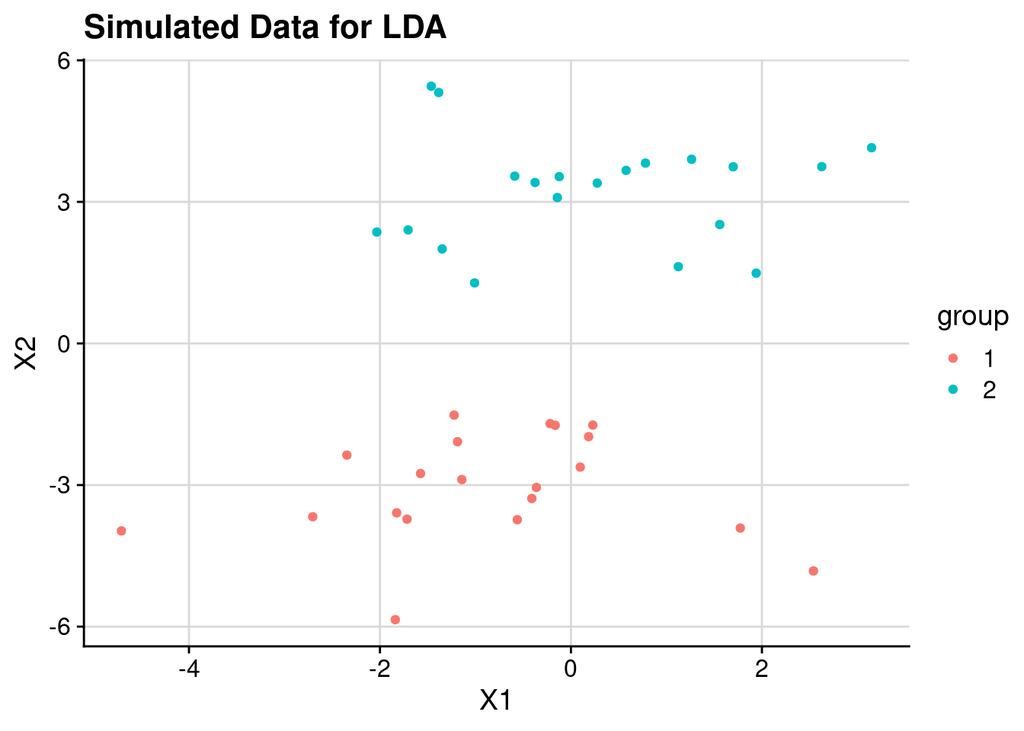

```r
set.seed(2025)
library(ggplot2); library(cowplot)

# Simulate two groups, p=2
n <- 20
Sigma <- matrix(c(3,0,0,1), 2, 2)
means <- list(c(-0.5,-3), c(0.5, 3))
dat <- do.call(rbind, lapply(1:2, function(i){
  data.frame(group = factor(i),
             MASS::mvrnorm(n, mu = means[[i]], Sigma = Sigma))
}))
colnames(dat)[-1] <- c("X1","X2")
ggplot(dat, aes(x = X1, y = X2, color = group)) +
  geom_point() +
  theme_cowplot() +
  background_grid(major = "xy") +
  labs(title = "Simulated Data for LDA", x = "X1", y = "X2")
```

We now obtain the matrix $\symbf{W}^{-1}\symbf{B}$.

**Show/Hide Code**

```r
X  <- as.matrix(dat[,2:3])
g  <- length(unique(dat$group))
n_i <- table(dat$group)
bar_overall <- colMeans(X)
bar_group <- dat |>
  dplyr::group_by(group) |>
  dplyr::summarise(
    dplyr::across(starts_with("X"), mean),
    .groups = 'drop'
  ) |>
  dplyr::select(-group) |>
  as.matrix()
# `Reduce` is used to sum over the groups.
# The inner `lapply` call creates a list of matrices for each group, and then `Reduce` sums them up (which is what the `+` operator does).
B <- Reduce(`+`, lapply(1:g, function(i){
  n_i[i] * (bar_group[i,] - bar_overall) %*% t(bar_group[i,] - bar_overall)
}))
W <- Reduce(`+`, lapply(1:g, function(i){
  Xi <- X[dat$group==i,]
  cov(Xi) * (n_i[i]-1)
}))
```

We now extract the eigenvectors and scale with respect to $\symbf{W}$ to obtain the loading vectors.

**Show/Hide Code**

```r
# Eigen decomposition
eig_obj <- eigen(solve(W) %*% B)
eig_mat <- eig_obj$vectors |> Re()
S_pooled <- W / (sum(n_i) - g)
sd_vec <- diag(t(eig_mat) %*% S_pooled %*% eig_mat) |> sqrt()
eig_mat <- eig_mat %*% diag(1/sd_vec)
eig_mat |>
  signif(2) |>
  knitr::kable(
    col.names = c("LD1", "LD2"),
    caption = "Scaled eigenvectors of $W^{-1}B$ (Loading Vectors)"
  )
```

Scaled eigenvectors of $W^{-1}B$ (Loading Vectors)

| LD1 | LD2 |
| --- | --- |
| -0.051 | -0.65 |
| -0.870 | 0.11 |

If we plot just the first new variable, i.e. the first linear discriminant, we can see how well it separates the two groups.

**Show/Hide Code**

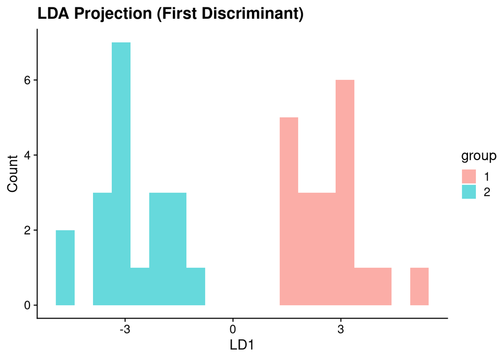

```r
dat$LD1 <- as.numeric(as.matrix(X) %*% eig_mat[,1])

# Plot LD1 histogram
ggplot(dat, aes(x = LD1, fill = group)) +
  geom_histogram(alpha = 0.6, position = "identity", bins = 20) +
  theme_cowplot() +
  labs(title = "LDA Projection (First Discriminant)", x = "LD1", y = "Count")
```

Out of interest, the first principal component actually also weights heavily on the second variable, as even though the second variable has less within-group variance than the first, the between-group variance is much larger, making the overall variability of variable two larger:

**Show/Hide Code**

```r
eig_obj <- eigen(cov(X))
eig_obj$vectors[, 1:2] |>
  signif(2) |>
  knitr::kable(
    col.names = c("PC1", "PC2"),
    caption = "Eigenvectors of $X'X$ (Principal Components)"
  )
```

Eigenvectors of $X'X$ (Principal Components)

| PC1 | PC2 |
| --- | --- |
| 0.20 | -0.98 |
| 0.98 | 0.20 |

Returning to LDA, the plot of the first two linear discriminants is essentially the same as the plot of the raw data but with the axes flipped.

**Show/Hide Code**

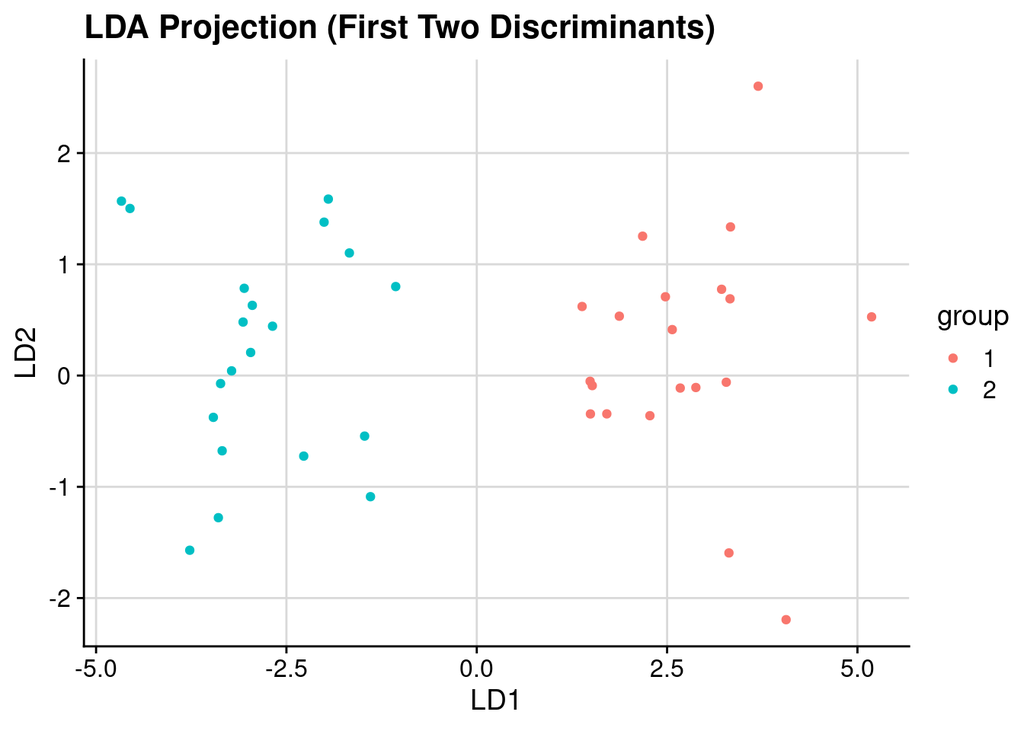

```r
dat$LD2 <- as.numeric(as.matrix(X) %*% eig_mat[,2])
ggplot(dat, aes(x = LD1, y = LD2, color = group)) +
  geom_point() +
  theme_cowplot() +
  background_grid(major = "xy") +
  labs(title = "LDA Projection (First Two Discriminants)", x = "LD1", y = "LD2")
```

Note that these loading vectors are the same as those from `MASS::lda`:

**Show/Hide Code**

```r
MASS::lda(group ~ ., data = dat[, 1:3])$scaling |> signif(2) |>
  knitr::kable(
    col.names = c("LD1", "LD2"),
    caption = "Loading Vectors from `MASS::lda`"
  )
```

Loading Vectors from `MASS::lda`

| LD1 | LD2 |
| --- | --- |
| X1 | 0.051 |
| X2 | 0.870 |

`MASS::lda` only returns the first linear discriminant, as there are two groups, which means we can get at most one linear discriminant that actually separates the two groups.

## Higher-dimensional, multi-group example

LDA is implemented in exactly the same way as the two-dimensional, two-group example. The only thing that is different is the number of groups and the number of variables. Here we have ten variables and five groups.

**Show/Hide Code**

```r
set.seed(2025)
library(ggplot2); library(cowplot)

# Simulate five groups, p = 10
n <- 20       # observations per group
p <- 10       # number of variables

# Common covariance: diagonal matrix with variance 3 on X1, and 1 on X2–X10
Sigma <- diag(c(3, rep(1, p - 1)))

# Define group means so that they differ along the first five dimensions
means <- lapply(1:5, function(i) {
  mu <- rep(0, p)
  mu[i] <- 3 * (i - 3)    # shifts: −6, −3, 0, 3, 6 on dimension i
  mu
})

# Simulate the data
dat <- do.call(rbind, lapply(1:5, function(i) {
  data.frame(
    group = factor(i),
    MASS::mvrnorm(n, mu = means[[i]], Sigma = Sigma)
  )
}))

# Name the columns X1…X10
colnames(dat)[-1] <- paste0("X", seq_len(p))

# Peek at the first few rows
head(dat)
```

```
  group        X1         X2          X3         X4          X5          X6
1     1 -4.924818  0.5402712  0.27979527 -0.6843955 -0.64065820  0.69042592
2     1 -5.938267  0.8854442  1.90725448 -1.9158754 -0.86385288 -0.25473083
3     1 -4.660857  1.4425273 -0.09792505  0.9352677 -0.42878593  1.04235775
4     1 -3.795984  0.6184340 -0.09607699  0.6347353 -1.38938348  0.23701117
5     1 -5.357452 -1.5176350 -0.87204546 -0.3203387  0.25089707 -1.32723723
6     1 -6.282072 -1.0704582 -1.70739760 -0.6056149 -0.04501612 -0.07638499
             X7         X8         X9        X10
1 -1.1208930648  0.5945689  1.2731270 -0.2445707
2  1.4700430674  0.6391008  1.4622685  0.7337854
3  0.2052566210  0.4794219 -0.6110828  2.8527814
4 -1.0612418880  1.3730624 -0.3605532  0.6715253
5 -0.0009748315 -1.1476841 -1.5291518 -0.1158493
6 -0.0244471704 -2.4506985  1.1332638 -1.3013520
```

**Show/Hide Code**

```r
# Compute B and W
X  <- as.matrix(dat[, -1])
g  <- length(unique(dat$group))
n_i <- table(dat$group)
bar_overall <- colMeans(X)
bar_group <- dat |>
  dplyr::group_by(group) |>
  dplyr::summarise(
    # dplyr::across(starts_with("X"), mean),
    dplyr::across(everything(), mean),
    .groups = 'drop'
  ) |>
  dplyr::select(-group) |>
  as.matrix()
# `Reduce` is used to sum over the groups.
# The inner `lapply` call creates a list of matrices for each group, and then `Reduce` sums them up (which is what the `+` operator does).
B <- Reduce(`+`, lapply(1:g, function(i){
  n_i[i] * (bar_group[i,] - bar_overall) %*% t(bar_group[i,] - bar_overall)
}))
W <- Reduce(`+`, lapply(1:g, function(i){
  Xi <- X[dat$group==i,]
  cov(Xi) * (n_i[i]-1)
}))
```

**Show/Hide Code**

```r
# Eigen decomposition
eig_obj <- eigen(solve(W) %*% B)
eig_mat <- eig_obj$vectors |> Re()
S_pooled <- W / (sum(n_i) - g)
sd_vec <- diag(t(eig_mat) %*% S_pooled %*% eig_mat) |> sqrt()
eig_mat <- eig_mat %*% diag(1/sd_vec)
eig_mat <- eig_mat[, 1:2]

display_tbl <- data.frame(
  "Variable" = paste0("V", seq_len(nrow(eig_mat))),
  "LD1" = eig_mat[, 1] |> signif(2),
  "LD2" = eig_mat[, 2] |> signif(2)
)
display_tbl |>
  knitr::kable(
  col.names = c("Variable", "LD1", "LD2"),
  caption = "Scaled Eigenvectors of $W^{-1}B$ (Loading Vectors)"
)
```

Scaled Eigenvectors of $W^{-1}B$ (Loading Vectors)

| Variable | LD1 | LD2 |
| --- | --- | --- |
| V1 | 0.240 | 0.470 |
| V2 | 0.250 | -0.340 |
| V3 | -0.130 | -0.013 |
| V4 | -0.170 | 0.770 |
| V5 | 1.100 | -0.088 |
| V6 | 0.130 | -0.046 |
| V7 | -0.180 | -0.130 |
| V8 | -0.017 | -0.097 |
| V9 | 0.230 | 0.041 |
| V10 | 0.210 | -0.170 |

LD1 driven by V5 (1.1). LD2 is driven by V4 (0.77) and V1 (0.47).

**Show/Hide Code**

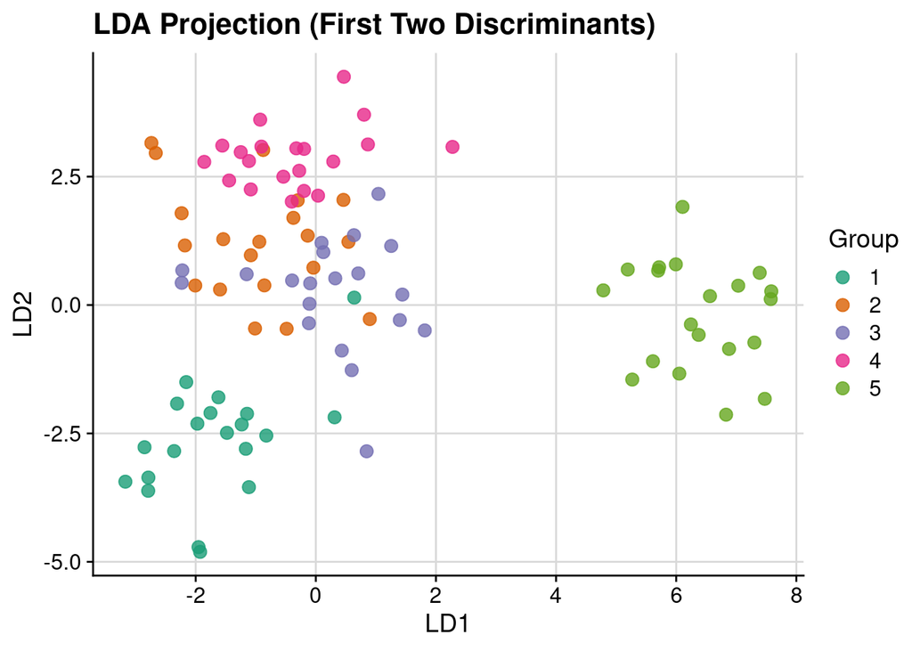

```r
dat$LD1 <- as.numeric(as.matrix(X) %*% eig_mat[,1])
dat$LD2 <- as.numeric(as.matrix(X) %*% eig_mat[,2])
col_vec <- c(
  "#1b9e77",
  "#d95f02",
  "#7570b3",
  "#e7298a",
  "#66a61e"
) |>
  toupper()
ggplot(dat, aes(x = LD1, y = LD2, color = group)) +
  geom_point(size =  3, alpha = 0.8) +
  theme_cowplot() +
  background_grid(major = "xy") +
  labs(title = "LDA Projection (First Two Discriminants)", x = "LD1", y = "LD2") +
  scale_colour_manual(
    values = col_vec,
    name = "Group"
  )
```

LD1 separates group 5 from the rest, indicating that group 5 is characterised by high levels of V5.

Here is the equivalent plot with the first two principal components:

**Show/Hide Code**

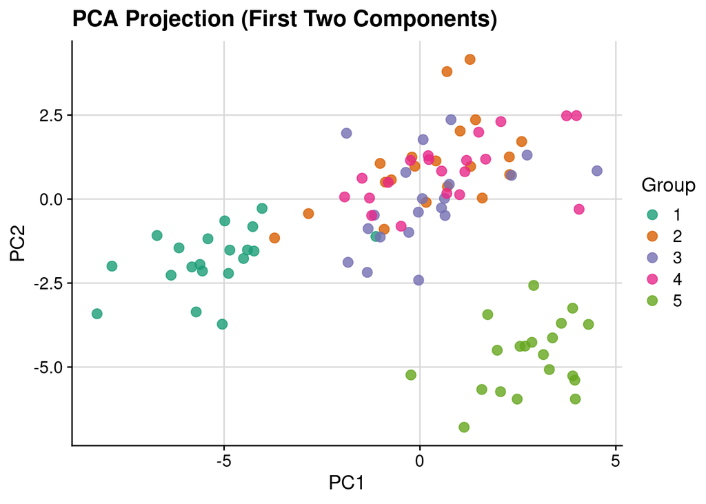

```r
eig_obj <- eigen(cov(X))
eig_obj_mat <- eig_obj$vectors[, 1:2] |>
  Re()
score_mat <- as.matrix(X) %*% eig_obj_mat
dat$PC1 <- score_mat[, 1]
dat$PC2 <- score_mat[, 2]
ggplot(dat, aes(x = PC1, y = PC2, color = group)) +
  geom_point(size =  3, alpha = 0.8) +
  theme_cowplot() +
  background_grid(major = "xy") +
  labs(title = "PCA Projection (First Two Components)", x = "PC1", y = "PC2") +
  scale_colour_manual(
    values = col_vec,
    name = "Group"
  )
```

We can see that `MASS::lda` produces the same loading vectors as we do:

**Show/Hide Code**

```r
MASS::lda(group ~ ., data = dat[, 1:11])$scaling[, 1:2] |>
  signif(2) |>
  knitr::kable(
    col.names = c("LD1", "LD2"),
    caption = "Loading Vectors from `MASS::lda`"
  )
```

Loading Vectors from `MASS::lda`

|  | LD1 | LD2 |
| --- | --- | --- |
| X1 | 0.240 | -0.470 |
| X2 | 0.250 | 0.340 |
| X3 | -0.130 | 0.013 |
| X4 | -0.170 | -0.770 |
| X5 | 1.100 | 0.088 |
| X6 | 0.130 | 0.046 |
| X7 | -0.180 | 0.130 |
| X8 | -0.017 | 0.097 |
| X9 | 0.230 | -0.041 |
| X10 | 0.210 | 0.170 |

It can now return two loading vectors as we have more than two groups, so we can have more than one linear discriminant that separates the groups.

# Summary

For the exam, the all you really need to be able to do is repeat the higher-dimensional, multi-group example above (apart from the simulation):

1. Calculate the between-class scatter matrix $\symbf{B}$ and the within-class scatter matrix $\symbf{W}$.
2. Obtain the eigenvectors of $\symbf{W}^{-1}\symbf{B}$, and scale them such that $\symbf{a}_i^\top\symbf{S}_{pooled}\symbf{a}_i=1$ for $\symbf{a}_i$ in the direction of the $i$-th eigenvector.
3. Interpret the scaled eigenvectors, as they are loading vectors.
4. Calculate the scores by taking the dot product of the data matrix with the eigenvectors.
5. Plot the first two scores to visualise class separation.
6. Interpret the plot in terms of class separation and the contributions of the original variables to observed separation.